# Birth Rate and Child Poverty in US Counties in 2022

Predicting birth rate and child poverty using maternal and childhood factors in 2022 data

Author

John Snell

Published

2024-02-16

## R Packages and Setup

```r
knitr::opts_chunk$set(comment = NA)

library(car)
library(gtsummary)
library(Hmisc)
library(janitor)
library(knitr)
library(naniar)
library(patchwork)
library(tidyverse)

theme_set(theme_bw())
```

# 1 Data Source

The data that we will be looking at come from two sources:

[County Health Rankings 2022 Data](https://www.countyhealthrankings.org/health-data/methodology-and-sources/rankings-data-documentation)

[CDC WONDER 2016-2022 Natality Data](https://wonder.cdc.gov/natality.html)

In order to access the CDC data, an agreement must be made in order to access the data, and then some categories must be marked in order to query specific data, which provides the columns of interest. Most columns were included in the query in the data that was downloaded. As a result of this, a local file needs to be produced for this data. The 2016-2022 data portal was selected. Results were grouped by County of Residence, and the measures “Birth Rate”, “Average Age of Mother (years)”, “Average Birth Weight (grams)”, “Average Pre-pregnancy BMI”, “Average Number of Prenatal Visits”, and “Average Interval Since Last Live Birth (months)” were selected. Results were exported, showing totals, zero values, and suppressed values, up to 3 decimal places in the data acquisition.

Natality data reflects nationwide records regarding births and infant data that result from county-level birth certificate records and associated maternal data. Data are updated annually.

County Health Rankings data is a composite collection of data from multiple sources. Following compiling of the data, weights are assigned to each county, z-scores are calculated, composite scores are created, and counties are then ranked. We are utilizing the functional “raw” versions of the data. Details about data collection methods can be found [here](https://www.countyhealthrankings.org/sites/default/files/media/document/2023%20CHRR%20Technical%20Document.pdf).

# 2 The Subjects

The subjects are amalgamated data for various counties from the United States of America, based on data availability for appropriate measures in respective datasets. The Natality data will contain the outcome of our linear regression, the birth rate, and the county health rankings data will contain the untransformed logistic regression outcome of childhood poverty percentage, for which we will be predicting if a county is above or below the national average of [16.3% in 2022](https://www.census.gov/library/stories/2023/12/poverty-rate-varies-by-age-groups.html). The final tibble will include 569 counties, which is driven by fewer counties being included in the Natality data than in the County Health Rankings data. Data are not exclusively adults, as the CDC WONDER database for Natality does not allow for exclusion of teenage mothers when querying the Natality 2016-2022 dataset for birth rate.

# 3 Loading and Tidying the Data

## 3.1 Loading the Raw Data

### 3.1.1 Elements We Will Collect

From the Natality data, we will want to utilize the following variables:

- County of Residence
  - Contains both county and state information. This data will be split into 2 variables
- Birth Rate
  - Number of births divided by total population in 2016-2022 data, multiplied by 1000
- Average Age of Mother (Years)
  - average age of mothers in that county
- Average Birth Weight (grams)
  - Average weight of newborn in grams
- Average Pre-pregnancy BMI
  - Average BMI value for mother pre-pregnancy
- Average Number of Prenatal Visits
  - Average number of doctor visits mother made before giving birth
- Average Interval Since Last Live Birth
  - Average number of months between birth events

From the County Health Rankings data, we will want to utilize the following variables:

- fipscode
  - Federal Information Processing Standard, will be used as identifier
- county
  - County name
- state
  - State name
- v024_rawvalue
  - Percent of children in poverty. Will be converted into factor based on whether county is above or below the national average
- v082_rawvalue
  - Percent of children in single parent households
- v128_rawvalue
  - Number of deaths among residents under age 18 per 100,000 population
- v122_rawvalue
  - Percentage of children under age 19 without health insurance
- v058_rawvalue
  - Percentage of population estimated to live in rural area based on census data. Will be turned into a factor variable.

### 3.1.2 Ingesting the Data

First, we will want to load in the data we will use. Because of the nature of the data that was pulled for natality, a local download needed to occur. Relevant files are submitted.

```r
natality2022 <- tibble(read_tsv("data/Natality, 2016-2022 expanded.txt"))
chr2022 <- tibble(read_csv("https://www.countyhealthrankings.org/sites/default/files/media/document/analytic_data2022.csv", skip = 1))
```

## 3.2 Cleaning the Data

### 3.2.1 Minor Corrections

Within the Natality data, a “notes” column with text descriptions exists, and all other variables are marked as ‘NA’ The Natality data also includes a pseudo-county for unincluded data, which will be removed. For the County Health Rankings data, each state, as well as the nation as a whole, are included as rows. Additionally, uncounted counties in the County Health Rankings data will not be included. I will want to remove the relevant lines from each dataset.

```r
USstates = c("United States",'Alabama','Alaska','Arizona',
  'Arkansas','California','Colorado','Connecticut',
  'Delaware','Florida','Georgia','Hawaii',
  'Idaho','Illinois','Indiana','Iowa',
  'Kansas','Kentucky','Louisiana','Maine',
  'Maryland','Massachusetts','Michigan','Minnesota',
  'Mississippi','Missouri','Montana','Nebraska',
  'Nevada','New Hampshire','New Jersey','New Mexico',
  'New York','North Carolina','North Dakota','Ohio',
  'Oklahoma','Oregon','Pennsylvania','Rhode Island',
  'South Carolina','South Dakota','Tennessee','Texas',
  'Utah','Vermont','Virginia','Washington',
  'West Virginia','Wisconsin','Wyoming')


natality2022 <- natality2022 |>
  select(-Notes) |>
  drop_na() |>
  filter(!`County of Residence` == "Unidentified Counties, CT") |> #data are all 0's for this pseudo county
  mutate(`Birth Rate` = na_if(`Birth Rate`, 'Not Available'))

chr2022 <- chr2022 |>
  filter(!county %in% USstates) |>
  filter(`county_ranked` == 1)
```

### 3.2.2 Selecting Variables We’ll Use

For the Natality data, we will first need to split the “County of Residence” data into 2 columns, as the state and county data currently exist as a composite variable. Otherwise, appropriate variables need to be selected for both Natality and County Health Rankings Data

```r
natality2022 <- cbind(natality2022,
                      str_split_fixed(natality2022$`County of Residence`, ", ", 2))
natality2022 <- natality2022 |>
  select('1',
        '2',
        'Birth Rate',
        'Average Age of Mother (years)',
        'Average Birth Weight (grams)',
        'Average Pre-pregnancy BMI',
        'Average Number of Prenatal Visits',
        'Average Interval Since Last Live Birth (months)')

chr2022 <- chr2022 |>
  select('fipscode',
         'county',
         'state',
         'v024_rawvalue', # children in poverty
         'v082_rawvalue', # children in single parent household
         'v128_rawvalue', # child mortality
         'v122_rawvalue', # uninsured children
         'v058_rawvalue') # percent rural
```

### 3.2.3 Changing Variable Names

Variables will now be given more appropriate names

```r
natality2022 <- natality2022 |>
  rename('county' = '1',
        'statecode' = '2',
        'birth_rt' = 'Birth Rate',
        'moth_age' = 'Average Age of Mother (years)',
        'birth_wgt' = 'Average Birth Weight (grams)',
        'preprg_bmi' = 'Average Pre-pregnancy BMI',
        'pren_vis' = 'Average Number of Prenatal Visits',
        'birth_int' = 'Average Interval Since Last Live Birth (months)') |>
  clean_names()

  chr2022 <- chr2022 |>
  rename('fipscode' = 'fipscode',
         'county' = 'county',
         'statecode' = 'state',
         'chld_pov' = 'v024_rawvalue',
         'chld_sph' = 'v082_rawvalue',
         'chld_mort' = 'v128_rawvalue',
         'chld_unin' = 'v122_rawvalue',
         'pct_rural' = 'v058_rawvalue') |>
  clean_names()
```

### 3.2.4 Combining the Data

Here, we will combine the two datasets into one larger one. We will also filter again for complete data.

```r
child2022 <- left_join(chr2022, natality2022, by=c('county','statecode'))

child2022 <- child2022 |>
  drop_na()
```

### 3.2.5 Correcting Percentages

For each percentage based variable, we will want to multiply them by 100 so that they are not in decimal form.

```r
child2022 <- child2022 |>
  mutate(chld_pov = chld_pov*100) |>
  mutate(chld_sph = chld_sph*100) |>
  mutate(chld_unin = chld_unin*100) |>
  mutate(pct_rural = pct_rural*100)
```

### 3.2.6 Creating Binary Value for Logistic Regression

For the Logistic regression, we will want to create a binary, for whether a county is above the national average child poverty percentage of 16.3% (yes) or not (no). This will be saved in the variable `hi_chld_pov`.

```r
child2022 <- child2022 |>
  mutate(hi_chld_pov = cut(chld_pov,
                            breaks = c(0,16.3,100),
                            labels = c("no","yes")))
```

### 3.2.7 Creating Factor for Percent Rural Called `urban`

In order to generate a categorical input, we will be grouping the `pct_rural` data into groups of how urban a county is:

- 0-10% = Very High
- 10-20% = High
- 20-30% = Medium
- 30-64.5% = Low (64.5% is most rural in dataset)

The new variable will be called `urban`. Additionally, the lower boundary is being set as -1, so that counties with a rural percentage of 0 are not excluded in the data.

```r
child2022 <- child2022 |>
  mutate(urban = cut(pct_rural,
                            breaks = c(-1,10,20,30,100),
                            labels = c("Very High","High","Medium","Low")))
```

### 3.2.8 Sampling the Data

Since our dataframe has 569 rows, we will not need to sample the data as there are between 100 and 1200 data points for us to consider.

### 3.2.9 Converting Variable Types

now, we need to check column data types.

```r
child2022
```

```
# A tibble: 569 × 16
   fipscode county     statecode chld_pov chld_sph chld_mort chld_unin pct_rural
   <chr>    <chr>      <chr>        <dbl>    <dbl>     <dbl>     <dbl>     <dbl>
 1 01003    Baldwin C… AL            12.4     18.4      51.2      3.41     42.3
 2 01015    Calhoun C… AL            16.7     31.0      57.9      2.98     33.7
 3 01055    Etowah Co… AL            22.9     34.1      64.9      3.72     37.5
 4 01069    Houston C… AL            23.4     32.8      83.6      3.08     33.8
 5 01073    Jefferson… AL            20.1     36.3      84.2      2.74      9.83
 6 01081    Lee County AL            16.8     26.9      64.8      3.56     27.4
 7 01089    Madison C… AL            13.5     26.8      54.6      3.16     16.4
 8 01097    Mobile Co… AL            27.3     35.9      68.6      2.67     20.0
 9 01101    Montgomer… AL            28.4     44.0      81.7      3.14     10.5
10 01103    Morgan Co… AL            20.1     24.1      59.6      4.12     38.6
# ℹ 559 more rows
# ℹ 8 more variables: birth_rt <chr>, moth_age <dbl>, birth_wgt <dbl>,
#   preprg_bmi <dbl>, pren_vis <dbl>, birth_int <dbl>, hi_chld_pov <fct>,
#   urban <fct>
```

`fipscode` needs to be converted to a character variable, `birth_rt` needs to be converted to a numeric variable, and `statecode` will be converted to a factor variable (although it doesn’t matter all too much for our purposes here).

```r
child2022 <- child2022 |>
  mutate(fipscode = as.character(fipscode)) |>
  mutate(birth_rt = as.numeric(birth_rt)) |>
  mutate(statecode = as.factor(statecode))

child2022
```

```
# A tibble: 569 × 16
   fipscode county     statecode chld_pov chld_sph chld_mort chld_unin pct_rural
   <chr>    <chr>      <fct>        <dbl>    <dbl>     <dbl>     <dbl>     <dbl>
 1 01003    Baldwin C… AL            12.4     18.4      51.2      3.41     42.3
 2 01015    Calhoun C… AL            16.7     31.0      57.9      2.98     33.7
 3 01055    Etowah Co… AL            22.9     34.1      64.9      3.72     37.5
 4 01069    Houston C… AL            23.4     32.8      83.6      3.08     33.8
 5 01073    Jefferson… AL            20.1     36.3      84.2      2.74      9.83
 6 01081    Lee County AL            16.8     26.9      64.8      3.56     27.4
 7 01089    Madison C… AL            13.5     26.8      54.6      3.16     16.4
 8 01097    Mobile Co… AL            27.3     35.9      68.6      2.67     20.0
 9 01101    Montgomer… AL            28.4     44.0      81.7      3.14     10.5
10 01103    Morgan Co… AL            20.1     24.1      59.6      4.12     38.6
# ℹ 559 more rows
# ℹ 8 more variables: birth_rt <dbl>, moth_age <dbl>, birth_wgt <dbl>,
#   preprg_bmi <dbl>, pren_vis <dbl>, birth_int <dbl>, hi_chld_pov <fct>,
#   urban <fct>
```

### 3.2.10 Arranging the Tibble

Now, we will want to rearrange the tibble in a more useful manner, as well as remove the redundant `chld_pov` and `pct_rural` variables.

```r
child2022 <- child2022 |>
  select(fipscode, county, statecode, birth_rt, moth_age, birth_wgt,
         preprg_bmi, birth_int, chld_sph, pren_vis, urban,
         hi_chld_pov, chld_mort, chld_unin)
dim(child2022)
```

```
[1] 569  14
```

# 4 The Tidy Tibble

## 4.1 Listing the Tibble

```r
child2022
```

```
# A tibble: 569 × 14
   fipscode county    statecode birth_rt moth_age birth_wgt preprg_bmi birth_int
   <chr>    <chr>     <fct>        <dbl>    <dbl>     <dbl>      <dbl>     <dbl>
 1 01003    Baldwin … AL            10.3     28.6     3231.       27.3      51.4
 2 01015    Calhoun … AL            11.6     27.2     3193.       29.4      52.1
 3 01055    Etowah C… AL            11.4     26.8     3222.       29.1      49.4
 4 01069    Houston … AL            11.6     27.1     3184.       30.2      49.8
 5 01073    Jefferso… AL            11.6     28.9     3155.       28.0      51.0
 6 01081    Lee Coun… AL            10.9     28.7     3194.       28.3      51.4
 7 01089    Madison … AL            11.2     29.2     3214.       28.4      49.7
 8 01097    Mobile C… AL            12.2     27.7     3117.       29.0      50.3
 9 01101    Montgome… AL            13.0     27.9     3079.       29.5      51.3
10 01103    Morgan C… AL            12.0     27.4     3188.       29.3      48.8
# ℹ 559 more rows
# ℹ 6 more variables: chld_sph <dbl>, pren_vis <dbl>, urban <fct>,
#   hi_chld_pov <fct>, chld_mort <dbl>, chld_unin <dbl>
```

## 4.2 Size and Identifiers

```r
identical(nrow(child2022),n_distinct(child2022))
```

```
[1] TRUE
```

## 4.3 Save The Tibble

```r
write_rds(child2022, "data/child2022.Rds")
```

Now that we have saved our data, we will do a little bit of garbage collection briefly.

```r
rm(USstates,chr2022,natality2022)
```

# 5 The Code Book

## 5.1 Defining the Variables

[output not shown]

### 5.1.1 Using `gtsummary` for a Partial Codebook

```r
tbl_summary(select(child2022, -c(fipscode, county, statecode)),
        label = list(
            birth_rt = "Birth Rate",
            moth_age = "Age of Mother (years)",
            birth_wgt = "Birth Weight (grams)",
            preprg_bmi = "Prepregnancy BMI",
            pren_vis = "Number of prenatal doctor visits",
            birth_int = "Time between last and current birth (months)",
            urban = "How Urban county is",
            chld_sph = "Percentage of children living in single parent households",
            hi_chld_pov = "hi_chld_pov (child poverty above national average)",
            chld_mort = "Child mortality per 100,000",
            chld_unin = "Percentage of children without health insurance"),
        stat = list( all_continuous() ~
                "{median} [{min} to {max}]" ))
```

| **Characteristic** | **N = 569**<sup>1</sup> |
| --- | --- |
| Birth Rate | 10.81 [5.17 to 18.93] |
| Age of Mother (years) | 29.28 [26.60 to 33.71] |
| Birth Weight (grams) | 3,253 [3,013 to 3,408] |
| Prepregnancy BMI | 28.03 [24.56 to 30.19] |
| Time between last and current birth (months) | 49.6 [37.5 to 65.3] |
| Percentage of children living in single parent households | 24 [10 to 52] |
| Number of prenatal doctor visits | 11.06 [8.71 to 14.72] |
| How Urban county is |  |
| Very High | 211 (37%) |
| High | 133 (23%) |
| Medium | 104 (18%) |
| Low | 121 (21%) |
| hi_chld_pov (child poverty above national average) | 216 (38%) |
| Child mortality per 100,000 | 46 [15 to 105] |
| Percentage of children without health insurance | 4.45 [1.18 to 16.21] |

<sup>1</sup> Median [Range]; n (%)

## 5.2 Numerical Description

```r
describe(child2022) |> html()
```

child2022  
14 Variables 569 Observations

fipscode

| n | missing | distinct |
| --- | --- | --- |
| 569 | 0 | 569 |

lowest : 01003 01015 01055 01069 01073 , highest: 55117 55127 55131 55133 55139

county

| n | missing | distinct |
| --- | --- | --- |
| 569 | 0 | 469 |

| lowest : | Ada County | Adams County | Aiken County | Alachua County | Alamance County |
| --- | --- | --- | --- | --- | --- |
| highest: | Yavapai County | Yellowstone County | Yolo County | York County | Yuma County |

statecode

| n | missing | distinct |
| --- | --- | --- |
| 569 | 0 | 49 |

lowest : AK AL AR AZ CA , highest: VA VT WA WI WV

birth_rt

| n | missing | distinct | Info | Mean | Gmd | .05 | .10 | .25 | .50 | .75 | .90 | .95 |
| --- | --- | --- | --- | --- | --- | --- | --- | --- | --- | --- | --- | --- |
| 569 | 0 | 543 | 1 | 10.93 | 2.079 | 8.310 | 8.700 | 9.707 | 10.811 | 12.054 | 13.157 | 13.731 |

lowest : 5.166 5.64 6.108 6.159 6.451 , highest: 17.243 17.331 18.736 18.904 18.934

moth_age

| n | missing | distinct | Info | Mean | Gmd | .05 | .10 | .25 | .50 | .75 | .90 | .95 |
| --- | --- | --- | --- | --- | --- | --- | --- | --- | --- | --- | --- | --- |
| 569 | 0 | 550 | 1 | 29.42 | 1.527 | 27.47 | 27.73 | 28.40 | 29.28 | 30.29 | 31.31 | 31.82 |

lowest : 26.602 26.608 26.813 26.835 26.841 , highest: 32.968 33.023 33.026 33.493 33.707

birth_wgt

| n | missing | distinct | Info | Mean | Gmd | .05 | .10 | .25 | .50 | .75 | .90 | .95 |
| --- | --- | --- | --- | --- | --- | --- | --- | --- | --- | --- | --- | --- |
| 569 | 0 | 568 | 1 | 3249 | 69.28 | 3145 | 3163 | 3213 | 3253 | 3292 | 3326 | 3344 |

lowest : 3013.08 3043.69 3045.14 3072.8 3073.19 , highest: 3376.55 3377 3383.69 3388.18 3407.94

preprg_bmi

| n | missing | distinct | Info | Mean | Gmd | .05 | .10 | .25 | .50 | .75 | .90 | .95 |
| --- | --- | --- | --- | --- | --- | --- | --- | --- | --- | --- | --- | --- |
| 569 | 0 | 522 | 1 | 27.93 | 1.054 | 26.31 | 26.60 | 27.40 | 28.03 | 28.57 | 29.09 | 29.32 |

lowest : 24.564 24.747 24.798 25.152 25.498 , highest: 29.81 29.998 30.058 30.187 30.193

birth_int

| n | missing | distinct | Info | Mean | Gmd | .05 | .10 | .25 | .50 | .75 | .90 | .95 |
| --- | --- | --- | --- | --- | --- | --- | --- | --- | --- | --- | --- | --- |
| 569 | 0 | 559 | 1 | 49.57 | 4.529 | 43.04 | 44.52 | 46.77 | 49.55 | 52.34 | 54.51 | 56.26 |

lowest : 37.471 38.239 39.133 39.612 40.119 , highest: 59.074 60.291 60.758 62.307 65.299

chld_sph

| n | missing | distinct | Info | Mean | Gmd | .05 | .10 | .25 | .50 | .75 | .90 | .95 |
| --- | --- | --- | --- | --- | --- | --- | --- | --- | --- | --- | --- | --- |
| 569 | 0 | 569 | 1 | 24.95 | 8.08 | 14.83 | 16.32 | 19.83 | 24.10 | 29.26 | 33.95 | 37.80 |

lowest : 10.2945 10.761 10.8249 10.8885 11.1746 , highest: 49.8363 51.0043 51.3883 51.6418 51.8981

pren_vis

| n | missing | distinct | Info | Mean | Gmd | .05 | .10 | .25 | .50 | .75 | .90 | .95 |
| --- | --- | --- | --- | --- | --- | --- | --- | --- | --- | --- | --- | --- |
| 569 | 0 | 528 | 1 | 11.11 | 1.1 | 9.601 | 9.823 | 10.480 | 11.058 | 11.685 | 12.342 | 12.851 |

lowest : 8.713 8.836 8.962 8.997 9.034 , highest: 13.93 13.979 14.071 14.712 14.719

urban

| n | missing | distinct |
| --- | --- | --- |
| 569 | 0 | 4 |

```
 Value      Very High      High    Medium       Low
 Frequency        211       133       104       121
 Proportion     0.371     0.234     0.183     0.213
```

hi_chld_pov

| n | missing | distinct |
| --- | --- | --- |
| 569 | 0 | 2 |

```
 Value        no  yes
 Frequency   353  216
 Proportion 0.62 0.38
```

chld_mort

| n | missing | distinct | Info | Mean | Gmd | .05 | .10 | .25 | .50 | .75 | .90 | .95 |
| --- | --- | --- | --- | --- | --- | --- | --- | --- | --- | --- | --- | --- |
| 569 | 0 | 569 | 1 | 48.74 | 16.43 | 27.93 | 30.79 | 38.62 | 46.48 | 57.36 | 68.91 | 75.99 |

lowest : 15.0624 21.4209 21.6958 22.1967 22.2585 , highest: 92.5355 93.9135 95.9831 100.548 105.282

chld_unin

| n | missing | distinct | Info | Mean | Gmd | .05 | .10 | .25 | .50 | .75 | .90 | .95 |
| --- | --- | --- | --- | --- | --- | --- | --- | --- | --- | --- | --- | --- |
| 569 | 0 | 569 | 1 | 5.201 | 2.82 | 2.147 | 2.678 | 3.389 | 4.454 | 6.370 | 8.868 | 11.252 |

lowest : 1.18266 1.41204 1.41386 1.48177 1.52637 , highest: 14.8778 15.3815 15.4564 15.722 16.2127

# 6 Linear Regression Plans

## 6.1 My First Research Question

Since the birth rate in an area can impact future economic factors, health opportunities, and educational opportunities, being able to predict the newborn cohort sizes has important governmental implications.

## 6.2 My Quantitative Outcome

The quantitative outcome that we will seek to predict will be `birth_rt` as observed in the `child2022` tibble. I am interested in predicting this variable since the number of births that occur in an area can impact future economic factors, health opportunities, and educational opportunities. Being able to predict the newborn cohort sizes has important governmental implications in regard to population dynamics.

In the `child2022` tibble, 569 rows contain complete information on this outcome.

### 6.2.1 Distribution of Outcome

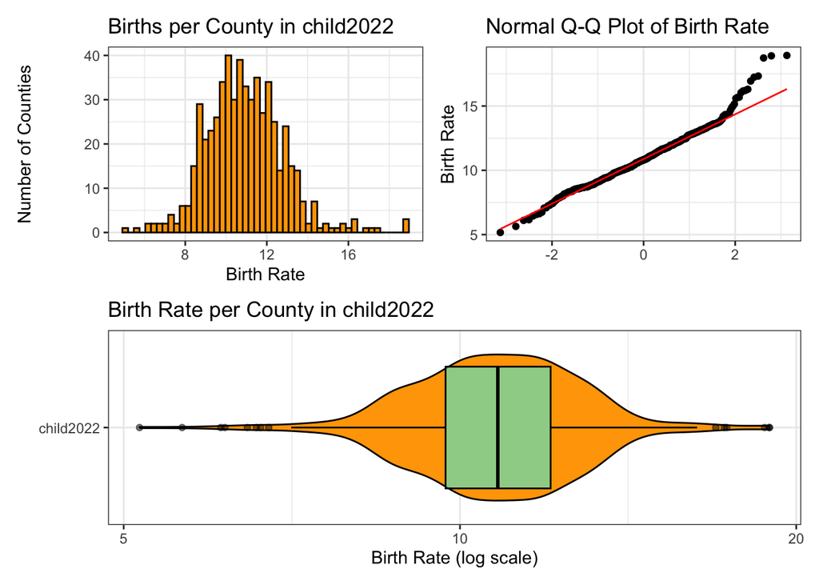

```r
plotA <- ggplot(child2022) +
  geom_histogram(aes(x = birth_rt), color = "black", fill = "orange", bins=50) +
  labs(x = "Birth Rate",
       y = "Number of Counties",
       title = "Births per County in child2022")
plotB <- ggplot(child2022) +
  geom_violin(aes(x = birth_rt, y = "child2022"), color = "black",fill = "orange") +
  geom_boxplot(aes(x = birth_rt, y = "child2022"), color = "black", fill = "cyan", alpha = .5) +
  scale_x_log10(labels = scales::comma) +
  labs(x = "Birth Rate (log scale)",
       y = "",
       title = "Birth Rate per County in child2022")
plotC <- ggplot(child2022, aes(sample = birth_rt)) +
  geom_qq(color = 'black') +
  geom_qq_line(color = 'red') +
  labs(x = '',
       y = 'Birth Rate',
       title = 'Normal Q-Q Plot of Birth Rate')

(plotA + plotC)/plotB
```

When looking at the outcome distribution, we observe a slight rightward skew in the data, with a median birth rate of 10.811, and a range of 5.166 to 18.934 The skew largely lies at the right end of the data, as is most apparent in the Q-Q plot curving upwards at the right end. It is also important to question if a transformation will be necessary, as there is some skew.

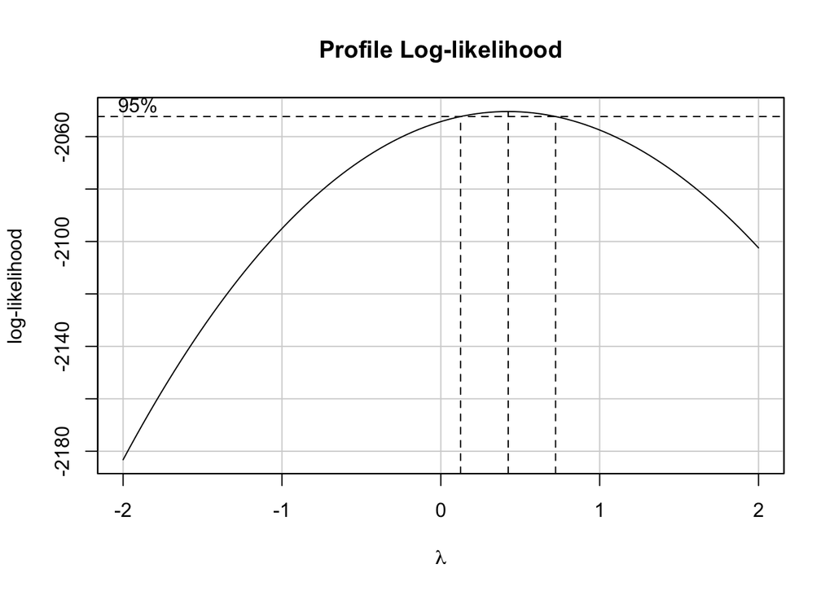

```r
boxCox(lm(birth_rt ~ moth_age + birth_wgt + preprg_bmi + pren_vis + birth_int + urban + chld_sph, data = child2022))
```

In order to correct the rightward skew, we would want to consider applying a square root of the outcome, as the apparent lambda is approximately 0.5.

## 6.3 My Planned Predictors (Linear Model)

- `moth_age` has 550 distinct values, and is measured in years.
- `birth_wgt` has 568 distinct values, and is measured in grams.
- `preprg_bmi` has 522 distinct values, and is measured in kg/m<sup>2</sup>.
- `pren_vis` has 528 distinct values.
- `birth_int` haprg_bmis 559 distinct values, and is measured in months.
- `urban` has 4 distinct values. There are 211 very high counties, 133 high counties, 104 medium counties, and 121 low counties. The origin variable for `urban`, `pct_rural` was removed from `child2022` earlier, and so is not influencing the result here.
- `chld_sph` has 569 distinct values.

To iterate on the number of entries per category in the `urban` variable:

```r
child2022 |>
  tabyl(urban) |>
  adorn_totals(where = c("row"))
```

```
     urban   n   percent
 Very High 211 0.3708260
      High 133 0.2337434
    Medium 104 0.1827768
       Low 121 0.2126538
     Total 569 1.0000000
```

In total, we are considering 7 predictive variables. The maximum number of variables we should consider is 4 + (N<sub>1</sub> - 100)/100. In this case, N<sub>1</sub> is the number of rows with complete outcome data, which is 569 rows with complete outcome data, and happens to be the entire tibble. Following the equation, we see 8.69 variables (rounded down to 8) should be permissible for our uses here. As we only have 7, we do not have too many predictor variables.

### 6.3.1 Anticipated Direction of Effects

I expect that the birth rate will be negatively correlated with `moth_age` (due to younger mothers having more children), positively correlated with `birth_wgt` (more healthy births having higher weights), negatively correlated with `preprg_bmi` (more births occuring with lower maternal BMIs), negatively correlated with `birth_int` (longer periods between births relate to fewer births), positively correlated with `pren_vis` (more doctors visits mean more chances of atching issues prior to birth), and negatively correlated with `chld_sph` (many single parent households being less likely to have more births). I also expect that high and very high `urban` groups will have more births, likely as a result of urban regions tending to have larger populations.

# 7 Logistic Regression Plans

## 7.1 My Second Research Question

How effectively can we predict whether or not a county’s child poverty rate is above the national average of 16.3% in 2022 based on the child mortality rate, the percentage of children without health insurance, the average number of prenatal doctors visits by mothers, the percentage of children in single parent households, and how urban the county is?

The ability to predict if a county’s child poverty rate is above or below the national average could be a useful tool in continuous tracking of overall outcomes for children as they grow older, and can also be indicative of where additional health care resources and educational resources may need to be diverted in the future.

## 7.2 My Binary Outcome

The logistic regression outcome will be `hi_chld_pov` in `child2022`. I am interested in predicting this variable as the ability to predict if a county’s child poverty rate is above or below the national average could be a useful tool in continuous tracking of overall outcomes for children as they grow older, and can also be indicative of where additional health care resources and educational resources may need to be diverted in the future.

For `hi_chld_pov`, we will want to check how many counties are above the national average (yes) and how many are below the national average (no).

```r
child2022 |>
  tabyl(hi_chld_pov) |>
  adorn_totals(where = c("row"))
```

```
 hi_chld_pov   n   percent
          no 353 0.6203866
         yes 216 0.3796134
       Total 569 1.0000000
```

Of these two variables, the lower is yes, with 216 represented measurements.

## 7.3 My Planned Predictors (Logistic Model)

The predictors I plan to use are `chld_mort`, `chld_unin`, `pren_vis`, `chld_sph`, and `urban`.

- `chld_mort` has 569 distinct values, and is measured in deaths per 100,000.
- `chld_unin` has 569 distinct values.
- `pren_vis` has 528 distinct values.
- `chld_sph` has 569 distinct values.
- `urban` has 4 distinct values. There are 211 very high counties, 133 high counties, 104 medium counties, 121 low counties, and 0 very low counties. The origin variable for `urban`, `pct_rural` was removed from `child2022` earlier, and so is not influencing the result here.

To iterate on the number of entries per category in the `urban` variable:

```r
child2022 |>
  tabyl(urban) |>
  adorn_totals(where = c("row"))
```

```
     urban   n   percent
 Very High 211 0.3708260
      High 133 0.2337434
    Medium 104 0.1827768
       Low 121 0.2126538
     Total 569 1.0000000
```

In total, we are considering 5 variables. The maximum number of variables we should consider is 4 + (N<sub>2</sub> - 100)/100. In this case, N<sub>2</sub> is the number of rows with complete outcome data for the smaller outcome group (yes), which is 216 rows with complete outcome data. Following the equation, we see 5.16 variables (rounded down to 5) should be permissible for our uses here. We have the maximum number of predictors that we should be using for our purposes here.

### 7.3.1 Anticipated Direction of Effects

I anticipate that high levels of child mortality will tend to correlate with higher poverty levels (`chld_sph`), and will be more likely to predict child poverty. I predict the high percentages of children without health insurance (`chld_unin`) will also predict higher levels of child poverty. I predict that low levels of prenatal visits (`pren_vis`) will also predict higher rates of child poverty, as mothers who cannot afford prenatal healthcare are more likely to be impoverished. I predict that counties with higher percentages of children in single parent households (`chld_sph`) will positively correlate with the higher rates of child poverty. I also predict that counties with low or very low `urban` levels will be more likely to exhibit child poverty, as there will be fewer opportunities for economic advancement.

# 8 Affirmation

I am certain that it is completely appropriate for these data to be shared with anyone, without any conditions. There are no concerns about privacy or security.

# 9 References

1. CDC Wonder Natality data from 2016-2022 are found at https://wonder.cdc.gov/natality.html.
2. County Health Rankings data for 2022 are found at https://www.countyhealthrankings.org/health-data/methodology-and-sources/rankings-data-documentation.
3. Information on the US national poverty rate can be found at https://www.census.gov/library/stories/2023/12/poverty-rate-varies-by-age-groups.html.